# 90 · Set test calibration

fry, camera and fgsea on the negative control, then on the contrasts

This stage sits beside the main pathway stages rather than inside their numbering. It reads only the upstream checkpoints (`proteins.rds`, `fit.rds`, `design.rds`) and its own frozen copy of the sets it tested, so it runs the same whichever layout of `03_Pathway_Enrichment` is merged. `92_Method_Comparison` puts its results next to the other set tests in the repository.

```r
required <- c("here", "limma", "fgsea", "dplyr", "tibble", "tidyr",
              "purrr", "readr", "ggplot2")
missing <- required[!vapply(required, requireNamespace, logical(1), quietly = TRUE)]
if (length(missing)) stop("Install required R packages: ", paste(missing, collapse = ", "))
library(here)
library(limma)
library(dplyr)
library(tibble)
library(tidyr)
library(purrr)
library(ggplot2)
here::i_am("03_Pathway_Enrichment/90_Set_Test_Calibration/a_script/90_set_test_calibration.qmd")

stage <- here("03_Pathway_Enrichment", "90_Set_Test_Calibration")
out <- file.path(stage, "c_data")
dir.create(out, recursive = TRUE, showWarnings = FALSE)

upstream <- c(
  proteins = "01_Preprocess/02_Quantification/c_data/proteins.rds",
  fit = "02_Differential_Expression/02_Differential/c_data/fit.rds",
  design = "02_Differential_Expression/01_Design/c_data/design.rds"
)
stopifnot("Run the upstream stages first" = all(file.exists(here(upstream))))
proteins <- readRDS(here(upstream[["proteins"]]))
fit <- readRDS(here(upstream[["fit"]]))
d <- readRDS(here(upstream[["design"]]))
design <- d$design
contrasts <- d$contrasts
control <- d$negative_control
contrast_names <- colnames(contrasts)
```

## The sets tested, frozen

The gene sets, the protein rows each set indexes, the per-contrast ranked t vectors and the gene-level matrix all come from `01_Gene_Sets/c_data/pathway_inputs.rds` as it stood on `main` at commit `fc2dc23` (MSigDB 2026.1.Hs; Hallmark, Reactome and GO:BP; at least 10 measured members; within-database Jaccard reduction). That file is being restructured in open pull requests, so the parts used here are copied once into `c_data/tested_sets.rds` and read from there. The copy records the md5 of the file it came from. `tested_sets.csv` is the same list in plain text, one row per set with its measured members, so anyone can check the sets without opening R.

```r
frozen_path <- file.path(out, "tested_sets.rds")
if (!file.exists(frozen_path)) {
  source_rel <- "03_Pathway_Enrichment/01_Gene_Sets/c_data/pathway_inputs.rds"
  stopifnot("pathway_inputs.rds from main @ fc2dc23 is needed once, to freeze the sets" =
              file.exists(here(source_rel)))
  x <- readRDS(here(source_rel))
  saveRDS(list(
    gene_sets = x$gene_sets, set_indices = x$set_indices, ranked_t = x$ranked_t,
    gene_matrix = x$gene_matrix, protein_map = x$protein_map,
    source = list(path = source_rel, md5 = unname(tools::md5sum(here(source_rel))),
                  frozen_utc = format(Sys.time(), tz = "UTC", usetz = TRUE),
                  provenance = x$provenance)
  ), frozen_path, compress = "xz")
  rm(x)
}
sets <- readRDS(frozen_path)

stopifnot(
  control %in% contrast_names,
  identical(rownames(design), colnames(proteins$E)),
  identical(rownames(fit$coefficients), rownames(proteins$E)),
  length(sets$set_indices) == length(sets$gene_sets),
  identical(names(sets$set_indices), names(sets$gene_sets)),
  max(unlist(sets$set_indices)) <= nrow(proteins$E),
  setequal(names(sets$ranked_t), contrast_names)
)

tested_sets <- tibble(set_id = names(sets$gene_sets),
                      n_measured = lengths(sets$gene_sets),
                      genes = map_chr(sets$gene_sets, \(g) paste(sort(g), collapse = ";"))) |>
  separate_wider_delim(set_id, "|", names = c("database", "pathway"), cols_remove = FALSE) |>
  relocate(set_id)
readr::write_csv(tested_sets, file.path(out, "tested_sets.csv"))

# Column names must not shadow the objects the later columns read: inside tibble() each
# argument sees the ones before it, so a column called `proteins` would hide the EList.
tibble(n_proteins = nrow(proteins$E), n_samples = ncol(proteins$E),
       n_sets = length(sets$set_indices), n_contrasts = length(contrast_names),
       negative_control = control, frozen_from_md5 = sets$source$md5)
```

| n_proteins | n_samples | n_sets | n_contrasts | negative_control | frozen_from_md5 |
| --- | --- | --- | --- | --- | --- |
| 3042 | 131 | 1040 | 5 | BFR_vs_HLRT_at_T1 | e06048b8fd805f113a38d150ad0905ac |

```r
count(tested_sets, database, name = "sets")
```

| database | sets |
| --- | --- |
| GOBP | 778 |
| Hallmark | 41 |
| Reactome | 221 |

## The precision weights

`dpcDE()` calls `voomaLmFitWithImputation`, which turns the DPC-Quant standard errors into vooma precision weights and fits with them. Those weights are the only channel by which quantification uncertainty reaches a set test, and they cannot be rebuilt as `1 / standard.error^2` because vooma combines the standard errors with a fitted mean-variance trend.

`contrasts.fit()` drops `fit$weights`, which is why the fit looks unweighted at first glance. The weighted EList the model was fitted to survives as `fit$EList`, and the weights are there. They are read from the published fit rather than recomputed: refitting would risk quietly diverging from the protein-level results everyone has already read.

```r
w <- fit$EList$weights
stopifnot(!is.null(w), identical(dim(w), dim(proteins$E)),
          all(is.finite(w)), all(w > 0))

# limma reads y$weights, so attaching them to the EList avoids depending on an argument name.
y <- proteins
y$weights <- w
tibble(weight_min = signif(min(w), 3),
       weight_median = signif(median(w), 3),
       weight_max = signif(max(w), 3),
       weight_ratio = signif(max(w) / min(w), 3))
```

| weight_min | weight_median | weight_max | weight_ratio |
| --- | --- | --- | --- |
| 0.265 | 5.23 | 396 | 1490 |

The ratio between the heaviest and lightest observation is how much the quantification stage thinks these measurements differ in reliability. A ratio near 1 would mean the weights change nothing and the whole limpa argument collapses at this step.

## The three families

| Family | Function | Assumes | Uses the design |
| --- | --- | --- | --- |
| Self-contained, rotation | `fry` | nothing about other sets; rotates residuals | yes, with weights |
| Competitive, correlation-aware | `camera` | the set against the rest, inter-gene correlation estimated | yes, with weights |
| Preranked, competitive | `fgsea` | genes are exchangeable and independent | no, a ranked vector only |

Only fgsea returns an effect score, the normalised enrichment score (NES): its sign is the direction and its size how tightly the set’s proteins sit at one end of the ranked list. fry and camera return a direction and a p-value only, so their NES column is left empty.

`fgsea` is here as the comparator, not as a candidate. It receives `ranked_t`, a vector, and has no way to know that participants contributed four samples each.

```r
run_fry <- function(cn) {
  fry(y, index = sets$set_indices, design = design, contrast = contrasts[, cn]) |>
    rownames_to_column("set_id") |>
    transmute(set_id, contrast = cn, method = "fry", n = NGenes,
              direction = Direction, NES = NA_real_, p = PValue)
}
run_camera <- function(cn) {
  camera(y, index = sets$set_indices, design = design, contrast = contrasts[, cn]) |>
    rownames_to_column("set_id") |>
    transmute(set_id, contrast = cn, method = "camera", n = NGenes,
              direction = Direction, NES = NA_real_, p = PValue)
}
run_fgsea <- function(cn) {
  set.seed(42)
  fgsea::fgsea(pathways = sets$gene_sets, stats = sets$ranked_t[[cn]],
               minSize = 1, maxSize = Inf, eps = 0) |>
    as_tibble() |>
    transmute(set_id = pathway, contrast = cn, method = "fgsea", n = size,
              direction = if_else(NES > 0, "Up", "Down"), NES = NES, p = pval)
}
runners <- list(fry = run_fry, camera = run_camera, fgsea = run_fgsea)

# Set-level FDR is always applied within one method, one contrast and one database. The three
# databases are separate families; Hallmark is the primary one, declared before any test ran.
add_fdr <- function(df) {
  df |>
    separate_wider_delim(set_id, "|", names = c("database", "pathway"), cols_remove = FALSE) |>
    mutate(padj = p.adjust(p, "BH"), .by = c(method, contrast, database))
}
control_results <- map(runners, \(f) f(control)) |> list_rbind() |> add_fdr()
```

## The negative control

BFR_vs_HLRT_at_T1 compares the two legs of the same person before either was trained. Treatment was counterbalanced, so the labels are exchangeable and the truth is that nothing separates them. A test is calibrated here or it is not calibrated.

```r
control_summary <- control_results |>
  summarise(
    sets = n(),
    sig = sum(padj < params$set_fdr),
    min_padj = signif(min(padj), 3),
    median_p = round(median(p), 3),
    p_below_05 = round(mean(p < 0.05), 3),
    .by = method
  ) |>
  mutate(verdict = if_else(sig <= params$control_tolerance, "passes", "FAILS"))
control_summary
```

| method | sets | sig | min_padj | median_p | p_below_05 | verdict |
| --- | --- | --- | --- | --- | --- | --- |
| fry | 1040 | 0 | 9.64e-01 | 0.583 | 0.016 | passes |
| camera | 1040 | 1 | 2.40e-06 | 0.539 | 0.043 | passes |
| fgsea | 1040 | 3 | 1.32e-05 | 0.517 | 0.059 | passes |

Under a true null the p-values are uniform: median near 0.5 and about 5% below 0.05. A method far above that is finding structure that is not there. A method far below it is conservative, which is not a disqualification but bounds what its silence on the interaction can mean.

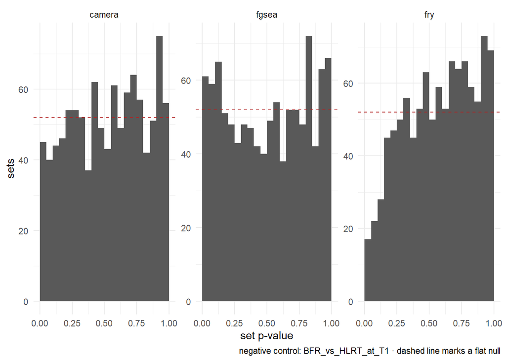

```r
ggplot(control_results, aes(p)) +
  geom_histogram(binwidth = 0.05, boundary = 0, fill = "grey35") +
  geom_hline(aes(yintercept = h),
             summarise(control_results, h = n() / 20, .by = method),
             linetype = 2, colour = "firebrick") +
  facet_wrap(~method, scales = "free_y") +
  labs(x = "set p-value", y = "sets",
       caption = paste("negative control:", control, "· dashed line marks a flat null")) +
  theme_minimal()
```

```r
control_results |>
  filter(padj < params$set_fdr) |>
  slice_min(padj, n = 15) |>
  transmute(method, set_id, n, direction, NES = round(NES, 2), padj = signif(padj, 3))
```

| method | set_id | n | direction | NES | padj |
| --- | --- | --- | --- | --- | --- |
| camera | Reactome\|REACTOME_STRIATED_MUSCLE_CONTRACTION | 30 | Down | NA | 2.40e-06 |
| fgsea | Reactome\|REACTOME_STRIATED_MUSCLE_CONTRACTION | 30 | Down | -2.52 | 1.32e-05 |
| fgsea | Reactome\|REACTOME_MUSCLE_CONTRACTION | 86 | Down | -1.81 | 1.45e-02 |
| fgsea | Hallmark\|HALLMARK_HEME_METABOLISM | 65 | Down | -1.84 | 2.91e-02 |

Sets listed above are false positives by construction. An empty table is the outcome to hope for.

## The contrasts, for methods that passed

```r
passed <- control_summary$method[control_summary$verdict == "passes"]
if (!length(passed)) {
  stop("No set-test method passed the negative control. Nothing here can be interpreted; ",
       "revisit the method before touching the interaction.")
}
other_contrasts <- setdiff(contrast_names, control)
results <- map(passed, \(nm) map(other_contrasts, runners[[nm]]) |> list_rbind()) |>
  list_rbind() |>
  add_fdr() |>
  bind_rows(filter(control_results, method %in% passed))
cat("Methods carried forward:", paste(passed, collapse = ", "),
    "\nMethods excluded by the control:",
    paste(setdiff(names(runners), passed), collapse = ", "), "\n")
```

```
Methods carried forward: fry, camera, fgsea
Methods excluded by the control:
```

FDR is applied within a method, within a contrast, and within a database. Hallmark is the primary collection, declared before these tests ran; Reactome and GO:BP are secondary. A set significant only in a secondary collection is a lead, not a result.

```r
results |>
  summarise(sig = sum(padj < params$set_fdr), .by = c(method, contrast, database)) |>
  pivot_wider(names_from = database, values_from = sig, values_fill = 0L) |>
  arrange(method, contrast)
```

| method | contrast | GOBP | Reactome | Hallmark |
| --- | --- | --- | --- | --- |
| camera | BFR_post_vs_pre | 49 | 35 | 3 |
| camera | BFR_vs_HLRT_at_T1 | 0 | 1 | 0 |
| camera | BFR_vs_HLRT_at_T2 | 23 | 9 | 4 |
| camera | HLRT_post_vs_pre | 17 | 18 | 1 |
| camera | interaction | 0 | 0 | 0 |
| fgsea | BFR_post_vs_pre | 82 | 46 | 5 |
| fgsea | BFR_vs_HLRT_at_T1 | 0 | 2 | 1 |
| fgsea | BFR_vs_HLRT_at_T2 | 45 | 21 | 5 |
| fgsea | HLRT_post_vs_pre | 32 | 38 | 3 |
| fgsea | interaction | 7 | 0 | 1 |
| fry | BFR_post_vs_pre | 205 | 58 | 8 |
| fry | BFR_vs_HLRT_at_T1 | 0 | 0 | 0 |
| fry | BFR_vs_HLRT_at_T2 | 0 | 0 | 0 |
| fry | HLRT_post_vs_pre | 170 | 60 | 5 |
| fry | interaction | 0 | 0 | 0 |

## Hallmark, the primary collection

One row per set and contrast, with every method side by side, so a set is read once rather than three times. `NES` comes from fgsea, the only method that returns an enrichment score: its sign is the direction and its size how tightly the set sits at one end of the ranked list. `methods` counts how many of the three called the set at FDR < 0.05; three is consensus.

```r
hallmark <- results |>
  filter(database == "Hallmark") |>
  select(contrast, pathway, n, method, direction, NES, padj) |>
  # fgsea counts members after matching to its ranked list, so its size can differ by one or two
  # from fry's; n is taken from fry and kept out of the pivot so the rows line up.
  pivot_wider(id_cols = c(contrast, pathway), names_from = method,
              values_from = c(n, direction, NES, padj)) |>
  transmute(
    contrast, pathway = sub("^HALLMARK_", "", pathway), n = n_fry,
    direction = coalesce(direction_fry, direction_fgsea),
    NES = round(NES_fgsea, 2),
    fgsea = signif(padj_fgsea, 2), fry = signif(padj_fry, 2), camera = signif(padj_camera, 2),
    methods = (padj_fgsea < params$set_fdr) + (padj_fry < params$set_fdr) +
      (padj_camera < params$set_fdr)
  ) |>
  filter(methods > 0)

for (cn in unique(hallmark$contrast)) {
  hallmark |>
    filter(contrast == cn) |>
    arrange(direction == "Down", desc(methods), pmin(fgsea, fry, camera)) |>
    select(-contrast) |>
    knitr::kable(caption = cn, format = "pipe") |>
    cat(sep = "\n")
  cat("\n\n")
}
```

BFR_post_vs_pre

| pathway | n | direction | NES | fgsea | fry | camera | methods |
| --- | --- | --- | --- | --- | --- | --- | --- |
| OXIDATIVE_PHOSPHORYLATION | 174 | Up | 2.99 | 0.0e+00 | 0.00048 | 0.0000 | 3 |
| FATTY_ACID_METABOLISM | 100 | Up | 2.15 | 1.2e-05 | 0.01200 | 0.0079 | 3 |
| ADIPOGENESIS | 118 | Up | 1.63 | 1.7e-02 | 0.02800 | 0.1100 | 2 |
| PEROXISOME | 44 | Up | 1.54 | 2.6e-01 | 0.02800 | 0.2400 | 1 |
| MYOGENESIS | 117 | Down | -1.95 | 1.1e-04 | 0.03600 | 0.0079 | 3 |
| G2M_CHECKPOINT | 40 | Down | -1.73 | 4.7e-02 | 0.00430 | 0.1100 | 2 |
| KRAS_SIGNALING_DN | 17 | Down | -1.72 | 8.0e-02 | 0.00430 | 0.1500 | 1 |
| SPERMATOGENESIS | 19 | Down | -1.45 | 2.6e-01 | 0.02800 | 0.5400 | 1 |

HLRT_post_vs_pre

| pathway | n | direction | NES | fgsea | fry | camera | methods |
| --- | --- | --- | --- | --- | --- | --- | --- |
| OXIDATIVE_PHOSPHORYLATION | 174 | Up | 2.87 | 0.000 | 2.1e-05 | 0.000 | 3 |
| APICAL_JUNCTION | 54 | Up | 1.86 | 0.018 | 3.1e-02 | 0.073 | 2 |
| ALLOGRAFT_REJECTION | 35 | Up | 1.38 | 0.240 | 4.7e-02 | 0.400 | 1 |
| SPERMATOGENESIS | 19 | Down | -1.79 | 0.039 | 1.3e-05 | 0.096 | 2 |
| G2M_CHECKPOINT | 40 | Down | -1.44 | 0.140 | 1.1e-02 | 0.180 | 1 |

BFR_vs_HLRT_at_T2

| pathway | n | direction | NES | fgsea | fry | camera | methods |
| --- | --- | --- | --- | --- | --- | --- | --- |
| BILE_ACID_METABOLISM | 29 | Up | 1.92 | 0.01200 | 0.11 | 0.017 | 2 |
| FATTY_ACID_METABOLISM | 100 | Up | 1.68 | 0.01800 | 0.58 | 0.032 | 2 |
| MYOGENESIS | 117 | Down | -1.95 | 0.00029 | 0.58 | 0.016 | 2 |
| EPITHELIAL_MESENCHYMAL_TRANSITION | 64 | Down | -1.91 | 0.00250 | 0.64 | 0.017 | 2 |
| APICAL_JUNCTION | 54 | Down | -1.77 | 0.01600 | 0.64 | 0.130 | 1 |

interaction

| pathway | n | direction | NES | fgsea | fry | camera | methods |
| --- | --- | --- | --- | --- | --- | --- | --- |
| HEME_METABOLISM | 65 | Up | 1.87 | 0.015 | 0.88 | 0.22 | 1 |

BFR_vs_HLRT_at_T1

| pathway | n | direction | NES | fgsea | fry | camera | methods |
| --- | --- | --- | --- | --- | --- | --- | --- |
| HEME_METABOLISM | 65 | Down | -1.84 | 0.029 | 0.96 | 0.42 | 1 |

## Export

```r
readr::write_csv(results, file.path(out, "set_test_results.csv"))
readr::write_csv(control_summary, file.path(out, "negative_control_summary.csv"))
saveRDS(list(results = results, control = control_results,
             control_summary = control_summary, passed = passed,
             inputs = c(upstream, tested_sets = "c_data/tested_sets.rds"),
             inputs_md5 = c(tools::md5sum(here(upstream)), tested_sets = tools::md5sum(frozen_path)),
             parameters = params, session = sessionInfo()),
        file.path(out, "set_tests.rds"))
tibble(file = list.files(out), bytes = file.size(file.path(out, list.files(out))))
```

| file | bytes |
| --- | --- |
| negative_control_summary.csv | 170 |
| set_test_results.csv | 2583826 |
| set_tests.rds | 643867 |
| tested_sets.csv | 358487 |
| tested_sets.rds | 3177204 |